# Combines training jobs from CHTC for all for 1week window and 0 lead and v1

John Curtin & Kendra Wyant

2022-07-16

### Code Status

In (beta) use for glmnet, random forest, and xgboost

### Notes

This script aggregates all results/metrics for a batch or batches of jobs that train all model configurations for a specific outcome/label window.

### Set Up Environment

```r
study <- params$study
data_type <- params$data_type
window <- params$window
lead <- params$lead
version <- params$version
```

Packages for lab workflow

```r
library(conflicted) # detect and warn about function conflicts
conflict_prefer("filter", "dplyr")
conflict_prefer("select", "dplyr")
conflict_prefer("spec", "yardstick")
conflict_prefer("col_factor", "vroom")

library(here)  # establish project directory consistently as working directory
```

Packages for script

```r
library(tidyverse)
library(lubridate)
library(vroom)
library(purrr)
library(furrr)
library(janitor)
library(ggplot2)
library(kableExtra)
library(vip)

theme_set(theme_classic())
```

Absolute paths

```r
switch (Sys.info()[['sysname']],
        # PC paths
        Windows = {
          path_input <- str_c("P:/studydata/risk/chtc/", study)
          path_processed <- str_c("P:/studydata/risk/data_processed/", study)},

        # IOS paths
        Darwin = {
          path_input <- str_c("/Volumes/private/studydata/risk/chtc/", study)
          path_processed <- str_c("/Volumes/private/studydata/risk/data_processed/", study)}
        )
```

Chunk Defaults

Source training controls

```r
source(here("../lab_support/chtc/static_files/input/fun_chtc.R"))
source(here("../lab_support/print_kbl.R"))
```

### Check for proper results, error, and output files

Will do this part in parallel as needed

```r
(n_core <- parallel::detectCores(logical = FALSE))
```

```
## [1] 20
```

```r
plan(multisession, workers = n_core)
```

#### Batch 1: GLMNET

```r
(batch_name <- str_c("train_", window, "_", lead, "_", version, "_glmnet"))
```

```
## [1] "train_1week_0_v1_glmnet"
```

Read in jobs file

```r
jobs <- vroom(here(path_input, batch_name, "input", "jobs.csv"), show_col_types = FALSE)

(n_jobs <- nrow(jobs))
```

```
## [1] 220
```

```r
err_files <- map_dfr(list.files(here(path_input, batch_name, "output", "error"),
                               full.names = TRUE),
                    file.info)
n_err_files <- nrow(err_files)

results_files <- map_dfr(list.files(here(path_input, batch_name, "output", "results"),
                               full.names = TRUE),
                    file.info)
n_results_files <- nrow(results_files)
```

Check counts of error and results

```r
if (!(n_jobs == n_err_files)) {
  stop(n_jobs, " jobs != ", n_err_files, " error files!")
} else {
  message(n_err_files, " error files detected.  Correct!")
}
```

```
## 220 error files detected.  Correct!
```

```r
if (!(n_jobs == n_results_files)) {
  stop(n_jobs, " jobs != ", n_results_files, " feature files!")
} else {
  message(n_results_files, " results files detected.  Correct!")
}
```

```
## 220 results files detected.  Correct!
```

Display path/filename of non-zero error files

```r
err_files %>%
    filter(size > 0) %>%
    rownames_to_column("path") %>%
    pull(path)
```

```
## character(0)
```

read in all result CSVs

```r
metrics_raw_batch <- list.files(here(path_input, batch_name, "output", "results"),
                                full.names = TRUE) %>%
  future_map_dfr(read_csv, col_types = readr::cols())
```

Basic counts and checks

```r
job_nums <- as.numeric(unique(metrics_raw_batch$job_num))
if (!(n_jobs == length(job_nums))) {
  stop(n_jobs, " jobs != ", length(job_nums), "  job_nums in metrics!")
} else {
  message(length(job_nums), " unique job numbs detected.  Correct!")
}
```

```
## 220 unique job numbs detected.  Correct!
```

```r
metrics_raw_batch %>% tabyl(job_num)
```

```
##  job_num   n     percent
##        1 200 0.004545455
##        2 200 0.004545455
##        3 200 0.004545455
##        4 200 0.004545455
##        5 200 0.004545455
##        6 200 0.004545455
##        7 200 0.004545455
##        8 200 0.004545455
##        9 200 0.004545455
##       10 200 0.004545455
##       11 200 0.004545455
##       12 200 0.004545455
##       13 200 0.004545455
##       14 200 0.004545455
```

[output cut: 206 more lines]

```r
metrics_raw_batch %>% tabyl(n_repeat)
```

```
##  n_repeat     n percent
##         1 44000       1
```

```r
metrics_raw_batch %>% tabyl(n_fold)
```

```
##  n_fold    n percent
##       1 4400     0.1
##       2 4400     0.1
##       3 4400     0.1
##       4 4400     0.1
##       5 4400     0.1
##       6 4400     0.1
##       7 4400     0.1
##       8 4400     0.1
##       9 4400     0.1
##      10 4400     0.1
```

```r
metrics_raw_batch %>% tabyl(algorithm)
```

```
##  algorithm     n percent
##     glmnet 44000       1
```

```r
metrics_raw_batch %>% tabyl(feature_set)
```

```
##  feature_set     n percent
##          all 44000       1
```

```r
metrics_raw_batch %>% tabyl(hp1)
```

```
##   hp1    n    percent
##  0.05 4000 0.09090909
##  0.10 4000 0.09090909
##  0.20 4000 0.09090909
##  0.30 4000 0.09090909
##  0.40 4000 0.09090909
##  0.50 4000 0.09090909
##  0.60 4000 0.09090909
##  0.70 4000 0.09090909
##  0.80 4000 0.09090909
##  0.90 4000 0.09090909
##  1.00 4000 0.09090909
```

```r
metrics_raw_batch %>% tabyl(hp2)
```

```
##           hp2   n percent
##  0.0003354626 220   0.005
##  0.0003527508 220   0.005
##  0.0003709299 220   0.005
##  0.0003900459 220   0.005
##  0.0004101470 220   0.005
##  0.0004312840 220   0.005
##  0.0004535104 220   0.005
##  0.0004768821 220   0.005
##  0.0005014584 220   0.005
##  0.0005273012 220   0.005
##  0.0005544758 220   0.005
##  0.0005830508 220   0.005
##  0.0006130985 220   0.005
##  0.0006446947 220   0.005
##  0.0006779192 220   0.005
##  0.0007128560 220   0.005
##  0.0007495932 220   0.005
##  0.0007882237 220   0.005
##  0.0008288450 220   0.005
##  0.0008715598 220   0.005
##  0.0009164758 220   0.005
##  0.0009637066 220   0.005
##  0.0010133715 220   0.005
##  0.0010655959 220   0.005
##  0.0011205117 220   0.005
##  0.0011782575 220   0.005
##  0.0012389794 220   0.005
##  0.0013028305 220   0.005
##  0.0013699722 220   0.005
##  0.0014405741 220   0.005
##  0.0015148145 220   0.005
##  0.0015928808 220   0.005
##  0.0016749704 220   0.005
##  0.0017612904 220   0.005
##  0.0018520590 220   0.005
##  0.0019475054 220   0.005
##  0.0020478706 220   0.005
##  0.0021534081 220   0.005
##  0.0022643846 220   0.005
```

[output cut: 146 more lines]

```
##  3.6564122682 220   0.005
##  3.8448464545 220   0.005
##  4.0429916470 220   0.005
##  4.2513483052 220   0.005
##  4.4704426796 220   0.005
##  4.7008281413 220   0.005
##  4.9430865795 220   0.005
##  5.1978298713 220   0.005
##  5.4657014268 220   0.005
##  5.7473778148 220   0.005
##  6.0435704710 220   0.005
##  6.3550274951 220   0.005
##  6.6825355403 220   0.005
##  7.0269218005 220   0.005
##  7.3890560989 220   0.005
```

```r
metrics_raw_batch %>% tabyl(hp3)
```

```
##  hp3     n percent valid_percent
##   NA 44000       1            NA
```

```r
metrics_raw_batch %>% tabyl(resample)
```

```
##  resample     n percent
##    down_1 22000     0.5
##      up_1 22000     0.5
```

```r
metrics_raw_batch %>% tabyl(n_feats)
```

```
##  n_feats     n percent
##      622 44000       1
```

Add batch 1 to all metrics

```r
metrics_raw_all <- metrics_raw_batch
```

#### Batch 2: Random Forest

```r
(batch_name <- str_c("train_", window, "_", lead, "_", version, "_random_forest"))
```

```
## [1] "train_1week_0_v1_random_forest"
```

Read in jobs file

```r
jobs <- vroom(here(path_input, batch_name, "input", "jobs.csv"), show_col_types = FALSE)

(n_jobs <- nrow(jobs))
```

```
## [1] 300
```

```r
err_files <- map_dfr(list.files(here(path_input, batch_name, "output", "error"),
                               full.names = TRUE),
                    file.info)
n_err_files <- nrow(err_files)

results_files <- map_dfr(list.files(here(path_input, batch_name, "output", "results"),
                               full.names = TRUE),
                    file.info)
n_results_files <- nrow(results_files)
```

Check counts of error, out, and results

```r
if (!(n_jobs == n_err_files)) {
  stop(n_jobs, " jobs != ", n_err_files, " error files!")
} else {
  message(n_err_files, " error files detected.  Correct!")
}
```

```
## 300 error files detected.  Correct!
```

```r
if (!(n_jobs == n_results_files)) {
  stop(n_jobs, " jobs != ", n_results_files, " feature files!")
} else {
  message(n_results_files, " results files detected.  Correct!")
}
```

```
## 300 results files detected.  Correct!
```

Display path/filename of non-zero error files

```r
err_files %>%
    filter(size > 0) %>%
    rownames_to_column("path") %>%
    pull(path)
```

```
## character(0)
```

read in all result CSVs

```r
metrics_raw_batch <- list.files(here(path_input, batch_name, "output", "results"),
                                full.names = TRUE) %>%
  future_map_dfr(read_csv, col_types = readr::cols())
```

Basic counts and checks

```r
job_nums <- as.numeric(unique(metrics_raw_batch$job_num))
if (!(n_jobs == length(job_nums))) {
  stop(n_jobs, " jobs != ", length(job_nums), "  job_nums in metrics!")
} else {
  message(length(job_nums), " unique job numbs detected.  Correct!")
}
```

```
## 300 unique job numbs detected.  Correct!
```

```r
metrics_raw_batch %>% tabyl(job_num)
```

```
##  job_num n     percent
##        1 1 0.003333333
##        2 1 0.003333333
##        3 1 0.003333333
##        4 1 0.003333333
##        5 1 0.003333333
##        6 1 0.003333333
##        7 1 0.003333333
##        8 1 0.003333333
##        9 1 0.003333333
##       10 1 0.003333333
##       11 1 0.003333333
##       12 1 0.003333333
##       13 1 0.003333333
##       14 1 0.003333333
```

[output cut: 286 more lines]

```r
metrics_raw_batch %>% tabyl(n_repeat)
```

```
##  n_repeat   n percent
##         1 300       1
```

```r
metrics_raw_batch %>% tabyl(n_fold)
```

```
##  n_fold  n percent
##       1 30     0.1
##       2 30     0.1
##       3 30     0.1
##       4 30     0.1
##       5 30     0.1
##       6 30     0.1
##       7 30     0.1
##       8 30     0.1
##       9 30     0.1
##      10 30     0.1
```

```r
metrics_raw_batch %>% tabyl(algorithm)
```

```
##      algorithm   n percent
##  random_forest 300       1
```

```r
metrics_raw_batch %>% tabyl(feature_set)
```

```
##  feature_set   n percent
##          all 300       1
```

```r
metrics_raw_batch %>% tabyl(hp1)
```

```
##  hp1  n percent
##    2 60     0.2
##   10 60     0.2
##   20 60     0.2
##   30 60     0.2
##   40 60     0.2
```

```r
metrics_raw_batch %>% tabyl(hp2)
```

```
##  hp2   n   percent
##    2 100 0.3333333
##   15 100 0.3333333
##   30 100 0.3333333
```

```r
metrics_raw_batch %>% tabyl(hp3)
```

```
##   hp3   n percent
##  1500 300       1
```

```r
metrics_raw_batch %>% tabyl(resample)
```

```
##  resample   n percent
##    down_1 150     0.5
##      up_1 150     0.5
```

```r
metrics_raw_batch %>% tabyl(n_feats)
```

```
##  n_feats   n percent
##      615 300       1
```

Add batch 2 to all metrics

```r
metrics_raw_all <- metrics_raw_all %>%
  bind_rows(metrics_raw_batch)
```

#### Batch 3: XGBoost

```r
(batch_name <- str_c("train_", window, "_", lead, "_", version, "_xgboost"))
```

```
## [1] "train_1week_0_v1_xgboost"
```

Read in jobs file

```r
jobs <- vroom(here(path_input, batch_name, "input", "jobs.csv"), show_col_types = FALSE)

(n_jobs <- nrow(jobs))
```

```
## [1] 2240
```

```r
err_files <- map_dfr(list.files(here(path_input, batch_name, "output", "error"),
                               full.names = TRUE),
                    file.info)
n_err_files <- nrow(err_files)

results_files <- map_dfr(list.files(here(path_input, batch_name, "output", "results"),
                               full.names = TRUE),
                    file.info)
n_results_files <- nrow(results_files)
```

Check counts of error and results

```r
if (!(n_jobs == n_err_files)) {
  stop(n_jobs, " jobs != ", n_err_files, " error files!")
} else {
  message(n_err_files, " error files detected.  Correct!")
}
```

```
## 2240 error files detected.  Correct!
```

```r
if (!(n_jobs == n_results_files)) {
  stop(n_jobs, " jobs != ", n_results_files, " feature files!")
} else {
  message(n_results_files, " results files detected.  Correct!")
}
```

```
## 2240 results files detected.  Correct!
```

Display path/filename of non-zero error files

```r
err_files %>%
    filter(size > 0) %>%
    rownames_to_column("path") %>%
    pull(path)
```

```
## character(0)
```

read in all result CSVs

```r
metrics_raw_batch <- list.files(here(path_input, batch_name, "output", "results"),
                                full.names = TRUE) %>%
  future_map_dfr(read_csv, col_types = readr::cols())
```

Basic counts and checks

```r
job_nums <- as.numeric(unique(metrics_raw_batch$job_num))
if (!(n_jobs == length(job_nums))) {
  warning(n_jobs, " jobs != ", length(job_nums), "  job_nums in metrics!")
} else {
  message(length(job_nums), " unique job numbs detected.  Correct!")
}
```

```
## 2240 unique job numbs detected.  Correct!
```

```r
metrics_raw_batch %>% tabyl(job_num)
```

```
##  job_num n      percent
##        1 1 0.0004464286
##        2 1 0.0004464286
##        3 1 0.0004464286
##        4 1 0.0004464286
##        5 1 0.0004464286
##        6 1 0.0004464286
##        7 1 0.0004464286
##        8 1 0.0004464286
##        9 1 0.0004464286
##       10 1 0.0004464286
##       11 1 0.0004464286
##       12 1 0.0004464286
##       13 1 0.0004464286
##       14 1 0.0004464286
```

[output cut: 2226 more lines]

```r
metrics_raw_batch %>% tabyl(n_repeat)
```

```
##  n_repeat    n percent
##         1 2240       1
```

```r
metrics_raw_batch %>% tabyl(n_fold)
```

```
##  n_fold   n percent
##       1 224     0.1
##       2 224     0.1
##       3 224     0.1
##       4 224     0.1
##       5 224     0.1
##       6 224     0.1
##       7 224     0.1
##       8 224     0.1
##       9 224     0.1
##      10 224     0.1
```

```r
metrics_raw_batch %>% tabyl(algorithm)
```

```
##  algorithm    n percent
##    xgboost 2240       1
```

```r
metrics_raw_batch %>% tabyl(feature_set)
```

```
##  feature_set    n percent
##          all 2240       1
```

```r
metrics_raw_batch %>% tabyl(hp1)
```

```
##    hp1   n   percent
##  1e-04 320 0.1428571
##  1e-03 320 0.1428571
##  1e-02 320 0.1428571
##  1e-01 320 0.1428571
##  2e-01 320 0.1428571
##  3e-01 320 0.1428571
##  4e-01 320 0.1428571
```

```r
metrics_raw_batch %>% tabyl(hp2)
```

```
##  hp2   n percent
##    1 560    0.25
##    2 560    0.25
##    3 560    0.25
##    4 560    0.25
```

```r
metrics_raw_batch %>% tabyl(hp3)
```

```
##  hp3   n percent
##   20 560    0.25
##   30 560    0.25
##   40 560    0.25
##   50 560    0.25
```

```r
metrics_raw_batch %>% tabyl(resample)
```

```
##  resample    n percent
##    down_1 1120     0.5
##      up_1 1120     0.5
```

```r
metrics_raw_batch %>% tabyl(n_feats)
```

```
##  n_feats    n percent
##      622 2240       1
```

Add batch 3 to all metrics

```r
metrics_raw_all <- metrics_raw_all %>%
  bind_rows(metrics_raw_batch)
```

### Wrap up processing of raw metrics

back to sequential

```r
plan(sequential)
```

Save raw metrics file

```r
metrics_raw_all %>%
  vroom_write(here(path_processed, str_c("metrics_raw_train_", window, "_", lead, "_", version, ".csv")), delim = ",")
```

### Average metrics across folds for model configurations

```r
metrics_avg <- metrics_raw_all %>%
  group_by(algorithm, feature_set, hp1, hp2, hp3, resample) %>%
   summarize(across(c(accuracy, bal_accuracy, roc_auc, sens, spec, ppv, npv),
                    mean),
             n_jobs = n(), .groups = "drop") %>%
  relocate(n_jobs)
```

Brief check of job counts.  
Number of jobs should = folds X repeats

```r
metrics_avg %>%
  group_by(algorithm) %>%
  tabyl(n_jobs)
```

```
##  n_jobs    n percent
##      10 4654       1
```

Save average metrics

```r
metrics_avg %>%
  vroom_write(here(path_processed, str_c("metrics_avg_train_", window, "_", lead, "_", version, ".csv")), delim = ",")
```

### View best performing models

Best AUC for algorithms x feature sets

```r
metrics_avg %>%
  group_by(algorithm, feature_set, resample) %>%
  arrange(desc(roc_auc)) %>%
  slice(1) %>%
  ungroup %>%
  arrange(desc(roc_auc)) %>%
  print_kbl()
```

| n_jobs | algorithm | feature_set | hp1 | hp2 | hp3 | resample | accuracy | bal_accuracy | roc_auc | sens | spec | ppv | npv |
| --- | --- | --- | --- | --- | --- | --- | --- | --- | --- | --- | --- | --- | --- |
| 10 | xgboost | all | 0.01 | 4.00 | 50 | down_1 | 0.82 | 0.81 | 0.89 | 0.80 | 0.82 | 0.60 | 0.93 |
| 10 | random_forest | all | 20.00 | 30.00 | 1500 | down_1 | 0.85 | 0.76 | 0.88 | 0.60 | 0.93 | 0.73 | 0.87 |
| 10 | xgboost | all | 0.20 | 1.00 | 50 | up_1 | 0.82 | 0.81 | 0.88 | 0.79 | 0.83 | 0.60 | 0.92 |
| 10 | glmnet | all | 1.00 | 0.01 | NA | up_1 | 0.83 | 0.80 | 0.87 | 0.85 | 0.75 | 0.91 | 0.63 |
| 10 | glmnet | all | 1.00 | 0.01 | NA | down_1 | 0.83 | 0.80 | 0.87 | 0.85 | 0.74 | 0.91 | 0.63 |
| 10 | random_forest | all | 30.00 | 15.00 | 1500 | up_1 | 0.84 | 0.72 | 0.87 | 0.49 | 0.96 | 0.77 | 0.85 |

### Plot hyperparameters

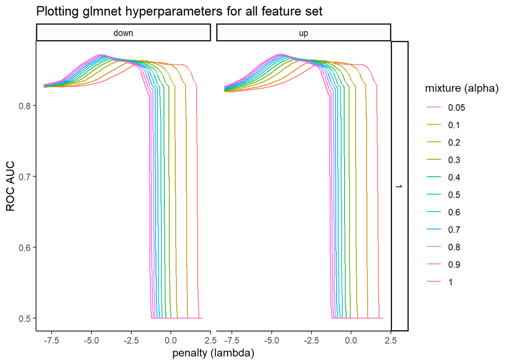

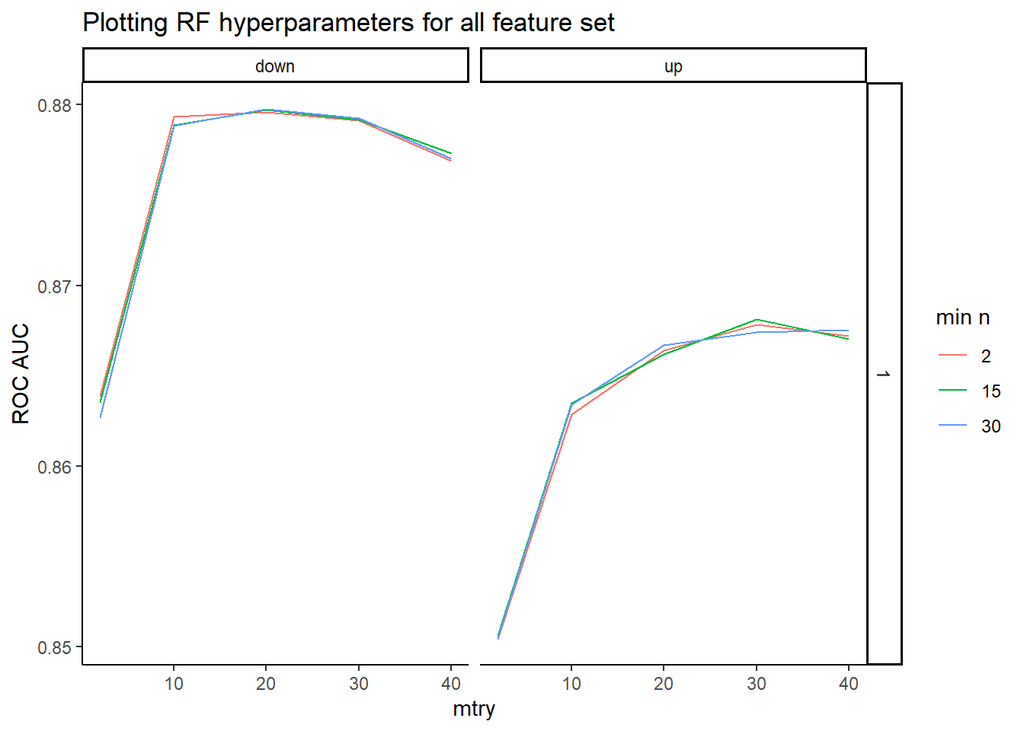

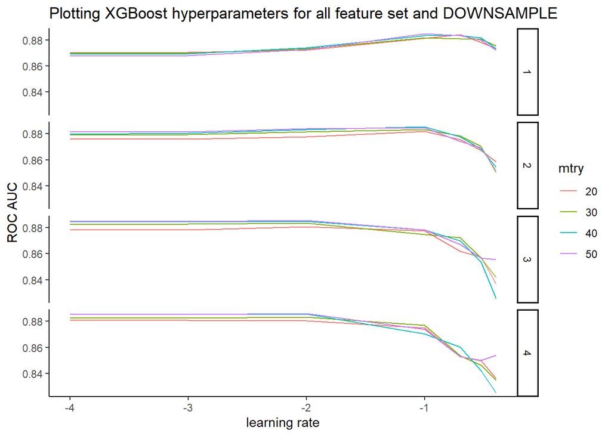

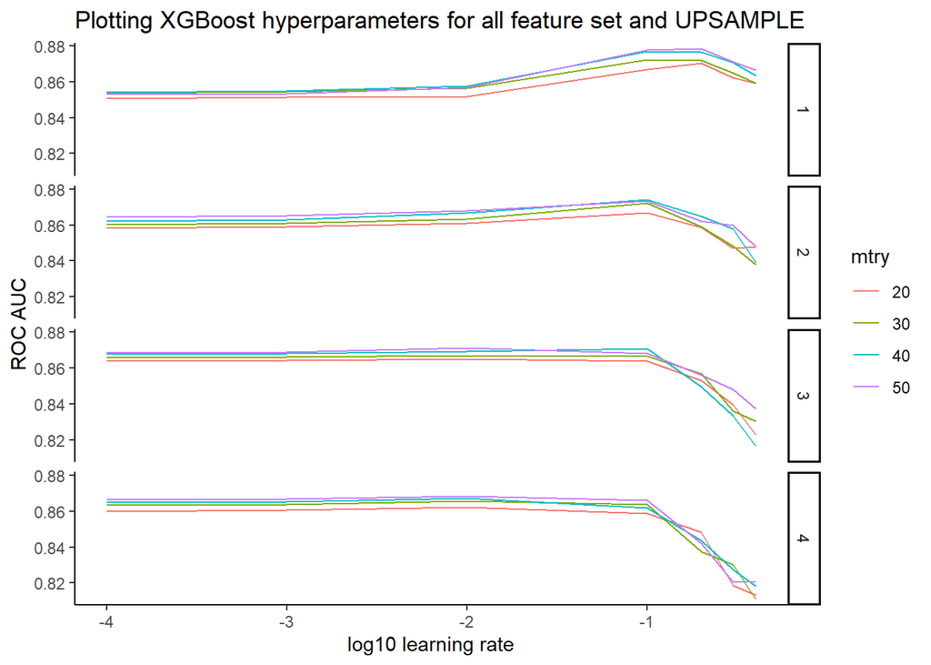

```r
algorithms <- unique(metrics_avg$algorithm)
feature_sets <- unique(metrics_avg$feature_set)

for (k in algorithms) {

  results_k <- metrics_avg %>%
      filter(algorithm == k)

  for (i in feature_sets) {

    results_i <- results_k %>%
      filter(feature_set == i)


    # glmnet
    if (k == "glmnet") {

      plot_title <- str_c("Plotting glmnet hyperparameters for ", i, " feature set")


      plot_i <- results_i %>%
        mutate(hp1 = factor(hp1, ordered = TRUE),
               resample = case_when(resample == "none" ~ "none_19",
                                    TRUE ~ resample)) %>%
        separate(resample, c("resample", "under_ratio"), "_") %>%
        mutate(under_ratio = factor(under_ratio, levels = c("1", "3", "19"))) %>%
        ggplot(mapping = aes(x = log(hp2),
                         y = roc_auc,
                         group = hp1,
                         color = hp1)) +
          geom_line() +
          facet_grid(under_ratio ~ resample) +
          scale_color_discrete(name = "mixture (alpha)") +
          labs(title = plot_title, x = "penalty (lambda)", y = "ROC AUC")

      print(plot_i)
    }

    # random forest
    if (k == "random_forest") {

      plot_title <- str_c("Plotting RF hyperparameters for ", i, " feature set")

      plot_i <- results_i %>%
        mutate(hp2 = factor(hp2, ordered = TRUE),
              resample = case_when(resample == "none" ~ "none_19",
                                    TRUE ~ resample)) %>%
        separate(resample, c("resample", "under_ratio"), "_") %>%
        mutate(under_ratio = factor(under_ratio, levels = c("1", "3", "19"))) %>%
        ggplot(mapping = aes(x = hp1,
                         y = roc_auc,
                         group = hp2,
                         color = hp2)) +
          geom_line() +
          facet_grid(under_ratio ~ resample) +
          scale_color_discrete(name = "min n") +
          labs(title = plot_title, x = "mtry", y = "ROC AUC")

       print(plot_i)
    }

    # XGBoost
    if (k == "xgboost") {

      plot_title <- str_c("Plotting XGBoost hyperparameters for ", i, " feature set and DOWNSAMPLE")
      plot_i <- results_i %>%
        mutate(log_hp1 = log10(hp1),
               hp2 = factor(hp2, ordered = TRUE),
               hp3 = factor(hp3, ordered = TRUE),
               resample = case_when(resample == "none" ~ "none_19",
                                    TRUE ~ resample)) %>%
        separate(resample, c("resample", "under_ratio"), "_") %>%
        mutate(under_ratio = factor(under_ratio, levels = c("1", "3", "19"))) %>%
        filter(resample == "down") %>%
        ggplot(mapping = aes(x = log_hp1,
                         y = roc_auc,
                         group = hp3,
                         color = hp3)) +
          geom_line() +
          facet_grid(vars(hp2)) +
          scale_color_discrete(name = "mtry") +
          labs(title = plot_title, x = "learning rate", y = "ROC AUC")

       print(plot_i)

      plot_title <- str_c("Plotting XGBoost hyperparameters for ", i, " feature set and UPSAMPLE")
      plot_i <- results_i %>%
        filter(!hp3 == 2) %>%
        mutate(log_hp1 = log10(hp1),
               hp2 = factor(hp2, ordered = TRUE),
               hp3 = factor(hp3, ordered = TRUE),
               resample = case_when(resample == "none" ~ "none_19",
                                    TRUE ~ resample)) %>%
        separate(resample, c("resample", "under_ratio"), "_") %>%
        mutate(under_ratio = factor(under_ratio, levels = c("1", "3", "19"))) %>%
        filter(resample == "up") %>%
        ggplot(mapping = aes(x = log_hp1,
                         y = roc_auc,
                         group = hp3,
                         color = hp3)) +
          geom_line() +
          facet_grid(vars(hp2)) +
          scale_color_discrete(name = "mtry") +
          labs(title = plot_title, x = "log10 learning rate", y = "ROC AUC")

       print(plot_i)
    }



    # # knn
    # if (k == "knn") {
    #
    #   plot_title <- str_c("Plotting knn hyperparameters for ", i, " feature set")
    #
    #   plot_i <- results_i %>%
    #     mutate(resample = case_when(resample == "none" ~ "none_19",
    #                                 TRUE ~ resample)) %>%
    #     separate(resample, c("resample", "under_ratio"), "_") %>%
    #     mutate(under_ratio = factor(under_ratio, levels = c("1", "3", "19"))) %>%
    #     ggplot(mapping = aes(x = hp1,
    #                      y = bal_accuracy)) +
    #       geom_line() +
    #       facet_grid(under_ratio ~ resample) +
    #       labs(title = plot_title, x = "neighbors", y = "balanced accuracy")
    #
    #     print(plot_i)
    # }
  }
}
```